# VL09: MLP: Delta-Regel, Backpropagation

IFM 5.6 Künstliche Intelligenz, 2017/18

Carsten Gips, FH Bielefeld

# Wiederholung

## Arbeitsweise Perzeptron

- Was ist ein Perzeptron? Wie funktioniert es?
- Wie wird ein Perzeptron trainiert?

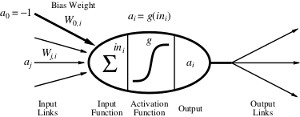

Quelle: [AIMA 3rd ed.](http://aima.cs.berkeley.edu)

$$\begin{array}{rcl}
y(\mathbf{x}) &=& \operatorname{g} \left(\sum_{i=1}^n w_i x_i - \theta \right)\\
&=& \operatorname{g}(\langle\mathbf{w},\mathbf{x}\rangle)
\end{array}$$

mit

- $w_0 = -\theta$
- $x_0=1$ (fest)
- $g(x) = \left\{ \begin{array}{ll} 0 & \text{falls } x<0\\ 1 & \text{sonst} \end{array} \right.$

**Lernregel**: $w_i \; \gets \; w_i + \eta \left(y_T^{(\alpha)} - y(\mathbf{x}^{(\alpha)}, \mathbf{w})\right) \cdot x^{(\alpha)}_i$

## Wiederholung (cnt.)

- Was ist ein (feedforward) MLP?
- Warum verwenden wir nicht einfach ein Perzeptron?
- Wie funktioniert ein MLP?

Tafel: Netz, Aktivierung, Feedforward-Phase

# Motivation

## Ableitung Fehlerfunktion

$$\nabla E(\mathbf{w}) = \left( \frac{\partial E}{\partial w_{0}}, \frac{\partial E}{\partial w_{1}}, \ldots, \frac{\partial E}{\partial w_{n}} \right)^T$$

## Backpropagation in MLP, Delta-Regel

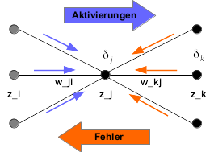

$\Delta w_{ji} = -\eta \delta_j z_i \qquad \text{mit} \quad \delta_j = z_j \cdot (1-z_j) \cdot \sum_k w_{kj} \delta_k$

## Themen für heute

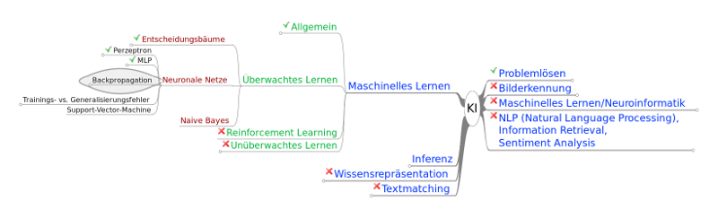

Am Ende der VL können/verstehen Sie:

- Delta-Regel: Änderung der Gewichte mit Gradientenabstieg
- Backpropagationsverfahren für MLP

# Backpropagation

## Erinnerung Ableitungsregeln

- Konstante Funktion: $\operatorname{y}(x) = c$ => $\dfrac{\operatorname{d} \operatorname{y}}{\operatorname{d} x} = 0$
- Konstanter Faktor: $\operatorname{y}(x) = c \cdot \operatorname{v}(x)$ => $\dfrac{\operatorname{d} \operatorname{y}}{\operatorname{d} x} = c \cdot \dfrac{\operatorname{d} \operatorname{v}}{\operatorname{d} x}$
- Summe/Differenz: $\operatorname{y}(x) = \operatorname{u}(x) \pm \operatorname{v}(x)$ => $\dfrac{\operatorname{d} \operatorname{y}}{\operatorname{d} x} = \dfrac{\operatorname{d} \operatorname{u}}{\operatorname{d} x} \pm \dfrac{\operatorname{d} \operatorname{v}}{\operatorname{d} x}$
- Produkt: $\operatorname{y}(x) = \operatorname{u}(x) \cdot \operatorname{v}(x)$ => $\dfrac{\operatorname{d} \operatorname{y}}{\operatorname{d} x} = \dfrac{\operatorname{d} \operatorname{u}}{\operatorname{d} x} \cdot \operatorname{v}(x) + \operatorname{u}(x) \cdot \dfrac{\operatorname{d} \operatorname{v}}{\operatorname{d} x}$
- Kettenregel: $\operatorname{y}(x) = \operatorname{u}(\operatorname{v}(x))$ => $\dfrac{\operatorname{d} y}{\operatorname{d} x} = \dfrac{\operatorname{d} y}{\operatorname{d} z} \cdot \dfrac{\operatorname{d} z}{\operatorname{d} x}$ mit $\operatorname{z} = \operatorname{v}(x)$ und $\operatorname{y} = \operatorname{u}(\operatorname{z})$
- Partielle Ableitung: $\nabla \operatorname{y}(\mathbf{w}) = \left( \dfrac{\partial \operatorname{y}}{\partial w_{0}}, \dfrac{\partial \operatorname{y}}{\partial w_{1}}, \ldots, \dfrac{\partial \operatorname{y}}{\partial w_{n}} \right)^T$

Tafel: Beispiele

## Nomenklatur MLP

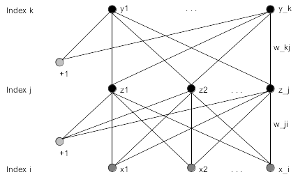

- Aktivierung Neuron $j$: $a_j = \sum_i w_{ji} z_i$
- Ausgabe von Neuron $j$: $z_j = g(a_j)$
- Transferfunktion: $g(a) = 1/(1+\exp(-a))$
- Ableitung: $g'(a) = g(a)(1-g(a))$

## Nomenklatur MLP: Schichten

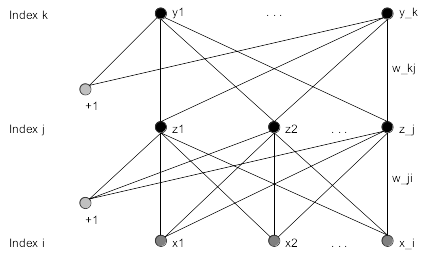

- Ausgabe-Schicht: Index $k$: $y_k = z_k = g(a_k) = g(\sum_j w_{kj} z_j)$
- Hidden Layer: Index $j$: $z_j = g(a_j) = g(\sum_i w_{ji} z_i)$
- Eingabe-Schicht: Index $i$: $z_i = x_i$
- $w_{kj}$: Gewicht gehört zu Neuron $k$, Verbindung zu Neuron $j$

## Gradientenabstieg (Erinnerung)

- **Ziel**: Verändere Gewichte so, dass Fehler minimiert wird => Gradientenabstieg
- **Fehlerfunktion**:
  $$E(\mathbf{w}) = \sum_d E^{(d)} = \sum_d \frac{1}{2} (y^{(d)} - t^{(d)})^2$$
  - $t^{(d)}$ … vorgegebene Klasse aus dem Trainingsbeispiel Nr. $d$
  - $y^{(d)}$ … Ausgabe des Neurons zu Trainingsbeispiel Nr. $d$, d.h.
    $$y^{(d)} = y(\mathbf{x}^{(d)}) = g(a^{(d)}) = g(\langle\mathbf{w},\mathbf{x}^{(d)}\rangle)$$

*Anmerkung*: Zunächst Betrachtung nur eines Neurons

## Gradientenabstieg: Ändere die Gewichte (Erinnerung)

$$\mathbf{w} \gets \mathbf{w} + \Delta\mathbf{w}$$
mit
$$\Delta\mathbf{w} = -\eta\nabla E(\mathbf{w})$$

=> Gehe in Richtung des negativen Gradienten

($\eta$: Laufschrittweite, kleine positive Zahl, z.B. $0.05$)

$$\nabla E(\mathbf{w}) = \left( \frac{\partial E}{\partial w_{0}}, \frac{\partial E}{\partial w_{1}}, \ldots, \frac{\partial E}{\partial w_{n}} \right)^T$$

Tafelskizze

## Gradientenabstieg (Single Neuron)

$$\begin{array}{lll}
\dfrac{\partial E}{\partial w_{i}} & = & \dfrac{\partial}{\partial w_{i}} \sum_d E^{(d)} = \sum_d \dfrac{\partial E^{(d)}}{\partial w_{i}} = \sum_d \dfrac{\partial}{\partial w_{i}} \dfrac{1}{2}(y^{(d)} - t^{(d)})^{2} \\[11pt]
& = & \sum_d \dfrac{1}{2} \dfrac{\partial}{\partial a^{(d)}} (g(a^{(d)}) - t^{(d)})^{2} \cdot \dfrac{\partial a^{(d)}}{\partial w_{i}} \\[11pt]
& = & \sum_d (g(a^{(d)}) - t^{(d)}) \cdot \dfrac{\partial}{\partial a^{(d)}} (g(a^{(d)}) - t^{(d)}) \cdot x_{i}^{(d)} \\[22pt]
& = & \sum_{d} \underbrace{(y^{(d)} - t^{(d)}) \cdot g'}_{\displaystyle\delta^{(d)}} \cdot x_{i}^{(d)}
\end{array}$$

$\Delta w_i^{(d)} = -\eta\dfrac{\partial E^{(d)}}{\partial w_{i}} = -\eta\delta^{(d)} x_i^{(d)}$

## Gradientenabstieg: Delta-Regel (Single Neuron)

$\Delta w_i^{(d)} = -\eta\delta^{(d)} x_i^{(d)} \qquad \text{ mit } \;\;\; \delta^{(d)} = (y^{(d)} - t^{(d)}) \cdot g'$

auch: LMS (least-mean-square), Adaline-Regel, Widrow-Regel

**Varianten**:

- Gradientenabstieg: $\Delta w_i^{(d)}$ über alle Daten $d$ summieren, Update am Ende
- Stochastischer Gradientenabstieg: Update für jedes einzelne Beispiel $\mathbf{x}^{(d)}$

Hinweis: Vergleich mit Perzeptron-Lernregel

## Fehler und Lernregel für MLP

- **Fehler**: Summe über alle Ausgabeneurone $k$

  $$E = \sum_k E_k$$
  mit
  $$E_k = \sum_d E_k^{(d)} = \sum_d \frac{1}{2} (y_k^{(d)} - t_k^{(d)})^2$$

  *Hinweis*: Wie in der letzten VL besprochen wird der Fehler im normalen Gradientenabstieg über alle Trainingsvektoren (Laufindex $d$) summiert.

  Im Folgenden wird die Rechnung für die stochastische Variante durchgeführt, d.h. man “spart” sich die Summe über alle Trainingsvektoren und den zusätzlichen Index $d$. Die Rechnung könnte man aber genauso für den normalen Gradientenabstieg durchführen.
- **Lernregel (Gradientenabstieg)**

  $$w_{ji} \gets w_{ji} + \Delta w_{ji}$$
  mit
  $$\Delta w_{ji} = -\eta \frac{\partial E}{\partial w_{ji}}$$

  *Hinweis*: Diese Formel gilt für alle Gewichte des MLP. Wenn man den Schichten feste Indizes zuweist, muss man in der Formel die Indizes passend ersetzen.

## Ableitungen und Kettenregel

- Anwendung der Kettenregel:
  $$\frac{\partial E}{\partial w_{ji}} = \frac{\partial E}{\partial a_{j}} \frac{\partial a_{j}}{\partial w_{ji}}$$
  - Gewicht $w_{ji}$ gehört zu Neuron $j$ mit Aktivierung $a_j$
  - Fehler hängt von Aktivierung $a_j$ ab
- Einführung von Abkürzungen:
  $$\delta_j = \frac{\partial E}{\partial a_{j}}
  \qquad \qquad
  \frac{\partial a_{j}}{\partial w_{ji}} = \frac{\partial }{\partial w_{ji}} \sum_i w_{ji} z_i = z_i$$
- **Backpropagation-Regel**
  $$\Delta w_{ji} = -\eta \frac{\partial E}{\partial w_{ji}} = -\eta \delta_j z_i
  \qquad \text{mit} \quad
  \delta_j = \frac{\partial E}{\partial a_{j}}$$

## Backpropagation: Delta für Ausgabeschicht

*Hinweis*: Zur besseren Übersicht werden in den folgenden Berechnungen jeweils der Index $d$ und die Summe über alle Daten $d$ weggelassen.

Damit erfolgt die Berechnung für den Fall “*stochastischer* Gradientenabstieg” (Update der Gewichte nach jedem einzelnen Trainingsbeispiel). Für den “normalen” Gradientenabstieg muss lediglich der Index $d$ für $y^{(d)}_k$ bzw. $t^{(d)}_k$ und jeweils die Summe über alle Daten $d$ wieder eingeführt werden. Die Rechnung ändert sich ansonsten aber nicht.

$$\begin{array}{rcl}
\Delta w_{kj} &=& -\eta \delta_k z_j\\[22pt]
\delta_k &=& \dfrac{\partial E}{\partial a_{k}}\\[11pt]
&=& \dfrac{\partial }{\partial a_{k}} \dfrac{1}{2} \sum_k (y_k - t_k)^2\\[11pt]
&=& \dfrac{1}{2} \dfrac{\partial }{\partial a_{k}} (y_k - t_k)^2\\[11pt]
&=& \dfrac{1}{2} 2(y_k - t_k) \dfrac{\partial }{\partial a_{k}} (y_k - t_k)\\[22pt]
&=& (y_k - t_k) \cdot g'(a_k)
\end{array}$$

## Backpropagation: Delta für Hidden Layer

$$\begin{array}{rcl}
\Delta w_{ji} &=& -\eta \delta_j z_i\\[22pt]
\delta_j &=& \dfrac{\partial E}{\partial a_{j}}\\[11pt]
&=& \sum_k \dfrac{\partial E}{\partial a_{k}} \dfrac{\partial a_{k}}{\partial a_{j}}\\[11pt]
&=& \sum_k \delta_k \dfrac{\partial a_{k}}{\partial a_{j}}\\[11pt]
&=& \sum_k \delta_k \dfrac{\partial }{\partial a_{j}} \sum_j w_{kj} z_j\\[11pt]
&=& \sum_k \delta_k \dfrac{\partial }{\partial a_{j}} \sum_j w_{kj} g(a_j)\\[22pt]
&=& \sum_k \delta_k w_{kj} g'(a_j)
\end{array}$$

## Backpropagation in MLP

$\Delta w_{ji} = -\eta \delta_j z_i \qquad \text{mit} \quad \delta_j = \dfrac{\partial E}{\partial a_{j}}$

- Letzte Schicht: $\delta_k = g'(a_k) \cdot (y_k - t_k)$
- Hidden Layer: $\;\;\delta_j = g'(a_j) \cdot \sum_k \delta_k w_{kj}$

Sigmoide Transferfunktion: $g'(a) = g(a) \cdot (1-g(a))$

- Letzte Schicht: $\delta_k = y_k \cdot (1-y_k) \cdot (y_k - t_k)$
- Hidden Layer: $\;\;\delta_j = z_j \cdot (1-z_j) \cdot \sum_k w_{kj} \delta_k$

=> Warum nicht einfach Kettenregel für Hidden Layer?!

## Backpropagation in MLP (cnt.)

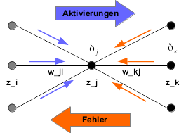

$\Delta w_{ji} = -\eta \delta_j z_i \qquad \text{mit} \quad \delta_j = z_j \cdot (1-z_j) \cdot \sum_k w_{kj} \delta_k$

## Lernen mit Backpropagation

1. Initialisierung: Gewichte mit kleinen Zufallszahlen initialisieren
2. Feedforward-Phase, Input durch das Netz propagieren
3. Backpropagations-Phase:
   - Berechnung der Deltas für die letzte Schicht
   - Propagieren der Deltas nach vorn durch das Netz
   - Korrektur der Gewichte
4. Abbruchkriterium oder gehe zu Schritt (2)

## Bemerkungen zu Backpropagation

- Differenzierbarkeit: Nutzung einer sigmoiden Transferfunktion
- Varianten
  - Normaler Gradientenabstieg: Summe der Gewichtsupdates über alle Daten und Update der Gewichte am Ende
  - Stochastischer Gradientenabstieg: Update nach jedem Trainingsvektor
- Initialisierung
  - Gewichte nicht zu groß: sonst Transferfunktion in Sättigung
  - Gewichte nicht zu klein: sonst Transferfunktion im linearen Bereich

Tafel: Skizze

# Zusammenfassung

## tl;dr

- Quadratische Fehlerfunktion, Abhängigkeit von Gewichten
- Gradientenabstieg: Gewichtsänderung zum Verringern der Fehler => Delta-Regel
- Backpropagation: Rückpropagieren der Fehleranteile und Gewichtsänderungen
  - Unterscheidung Gradientenabstieg und stochastischer Gradientenabstieg
  - Effizienz: Nutzung der Fehler der hinteren Schichten erspart das Neuberechnen dieser Fehler beim Berechnen der Fehler der weiter vorn liegenden Schichten, wie es bei der Anwendung der normalen Kettenregel der Fall wäre.
- MLP trainieren: abwechselnd Feedforward-Phase und Backpropagation-Phase

**Nächste Woche**: Crossvalidierung, Regularisierung, Anwendungen, SVM

## Bis nächstes Jahr :-)

Frohe Weihnachten und ...

... einen guten Start ins nächste Jahr!

**Hinweise**:

- Im nächsten Jahr noch fünf Vorlesungen:
  - VL10: **Selbststudium** [^1] (Crossvalidierung, Regularisierung, SVM)
  - VL11: 09. Januar (PK1: Syntax+Semantik, Folgern)
  - VL12: 16. Januar (Ableiten, Unifikation)
  - VL13: 23. Januar (Klauseln, Resolution, Einführung Prolog)
  - VL14: 30. Januar (Rückblick, Umfrage, Klausurvorbereitung)
- Im nächsten Jahr noch drei Praktika:
  - B08: Abgabe KW02 (09.01.18)
  - B09: Abgabe KW03 (16.01.18)
  - B10: Abgabe KW04 (23.01.18)
- Klausur: Di, 06.02.18, Raum H10, 09:00 – 10:30 Uhr
  - Zugelassene Materialien: handbeschriebener DIN-A4-Zettel und Stift (Insbesondere: kein Handy, …! => Bringen Sie sich eine Uhr mit.)

## Literatur zum Weiterlesen

- Russell, Norvig: “Artificial Intelligence: A Modern Approach, 3rd ed.”
  - MLP: Abschnitt 18.7
- Bishop: “Neural Networks for Pattern Recognition”, Oxford University Press
  - MLP: Kapitel 4

## Lernziele – Nach dieser Vorlesung sollten Sie …

### Verstehen (K2)

- Quadratische Fehlerfunktion über den Gewichten
- Gradientenabstieg: Delta-Regel zur Veränderung der Gewichte
- Backpropagation: Herleitung der Regeln, Anwendungung des Verfahrens, Vorteil gegenüber direktem Ableiten der Fehlerfunktion in den einzelnen Schichten
- Bedeutung der Initialisierung mit kleinen Gewichten

### Anwenden (K3)

- Berechnen der Deltas für die einzelnen Schichten und Gewichtsupdates
- Training der MLPs

## Diese Fragen sollten Sie beantworten können …

### Backpropagation

- Erklären Sie die Feedforward-Phase an einem Beispiel.
- Was bedeutet die Delta-Regel?
- Warum nutzen wir die Delta-Regel für die Backprogagation? Warum leiten wir die Fehler nicht einfach schichtweise ab?
- Rechnen Sie die Backpropagation-Regel für die erste Schicht nach.
- Erklären Sie die Backpropagations-Phase an einem Beispiel.
- Warum setzt man für MLPs eine sigmoide Transferfunktion ein? Warum kann man nicht einfach die Sprungfunktion (vom Perzeptron) nehmen?
- Was würde passieren, wenn man als Transferfunktion eine lineare Funktion einsetzen würde?
[^1]: Sie erhalten vorab die Unterlagen und arbeiten diese selbstständig zu Hause durch. Der Inhalt wird am Anfang von VL11 sowie im Praktikum zu B08 abgefragt bzw. kurz diskutiert.